# Laboratori R: Test de Neyman–Pearson per la Mitjana Normal (σ coneguda)

2026-04-29

## Enunciat

Siguin $X_1, X_2, \ldots, X_n \overset{\text{iid}}{\sim} \mathcal{N}(\mu, \sigma^2)$ amb desviació típica coneguda $\sigma = 1$. Considereu el contrast d’hipòtesis simples:

$$H_0: \mu = \mu_0 = 0 \qquad \text{vs} \qquad H_1: \mu = \mu_1 = 1$$

amb nivell de significació $\alpha = 0.05$.

S’ha observat la mostra següent de $n = 10$ realitzacions:

```
#> 2.371 0.435 1.363 1.633 1.404 0.894 2.512 0.905 3.018 0.937
```

**Tasques:**

1. Deriveu el test UMP a partir del Lema de Neyman–Pearson i justifiqueu la forma de la regió de rebuig.
2. Fixeu el valor crític $c$ per a $n = 10$ i $\alpha = 0.05$, i calculeu el nivell real del test.
3. Apliqueu el test a la mostra donada i preneu una decisió raonada.
4. Avalueu el rendiment del test amb $n = 100$ mitjançant 10000 experiments simulats: estimeu la probabilitat d’error de tipus I i la potència.
5. Representeu gràficament la potència del test en funció de $\mu_1 \in (\mu_0, 3)$.

## 1. Fonament teòric: Lema de Neyman–Pearson

Siguin $X_1, \ldots, X_n \overset{\text{iid}}{\sim} \mathcal{N}(\mu, \sigma^2)$ amb $\sigma$ coneguda.

### Funció de versemblança

La versemblança conjunta és el producte de les densitats normals individuals:

$$L(\mu \mid \mathbf{x}) = \prod_{i=1}^n \frac{1}{\sqrt{2\pi}\,\sigma}
\exp\!\left(-\frac{(x_i - \mu)^2}{2\sigma^2}\right)
= \left(\frac{1}{\sqrt{2\pi}\,\sigma}\right)^n
\exp\!\left(-\frac{\sum_{i=1}^n(x_i-\mu)^2}{2\sigma^2}\right)$$

### Raó de versemblances

El Lema de Neyman–Pearson estableix que el test UMP de nivell $\alpha$ rebutja $H_0$ quan:

$$\Lambda(\mathbf{x}) = \frac{L(\mu_1 \mid \mathbf{x})}{L(\mu_0 \mid
\mathbf{x})}
= \exp\!\left(-\frac{\sum(x_i-\mu_1)^2 -
\sum(x_i-\mu_0)^2}{2\sigma^2}\right) > k$$

Expandim la diferència de sumes de quadrats:

$$\sum(x_i - \mu_0)^2 - \sum(x_i - \mu_1)^2
= \sum\bigl[(x_i-\mu_0)^2 - (x_i-\mu_1)^2\bigr]
= \sum 2x_i(\mu_1 - \mu_0) - n(\mu_1^2 - \mu_0^2)$$

$$= 2n\bar{x}(\mu_1-\mu_0) - n(\mu_1-\mu_0)(\mu_1+\mu_0)
= n(\mu_1-\mu_0)\bigl[2\bar{x} - (\mu_1+\mu_0)\bigr]$$

Substituint a $\log\Lambda$:

$$\log\Lambda(\mathbf{x}) = \frac{n(\mu_1-\mu_0)}{2\sigma^2}\bigl[2\bar{x}
- (\mu_1+\mu_0)\bigr]$$
Com que $\mu_1 > \mu_0$, el coeficient $\frac{n(\mu_1-\mu_0)}{2\sigma^2} > 0$, de manera que $\log\Lambda$ és **estrictament creixent en $\bar{x}$**. Per tant, la condició $\Lambda > k$ és equivalent a:

$$\boxed{\bar{X} \geq c}$$

on $c$ es fixa per assolir el nivell $\alpha$.

## 2. Valor crític per $n = 10$ i $\alpha=0.05$

Sota $H_0$, la mitjana mostral segueix:

$$\bar{X} \sim \mathcal{N}\!\left(\mu_0,\, \frac{\sigma^2}{n}\right)
\qquad \Longrightarrow \qquad Z = \frac{\bar{X} -
\mu_0}{\sigma/\sqrt{n}} \sim \mathcal{N}(0,1)$$

El valor crític és:

$$c = \mu_0 + z_{1-\alpha}\,\frac{\sigma}{\sqrt{n}}$$

on $z_{1-\alpha} = \Phi^{-1}(1-\alpha)$ és el quantil $(1-\alpha)$ de la normal estàndard.

```r
alpha <- 0.05
n     <- 10
mu0   <- 0
mu1   <- 1
sigma <- 1

# Valor crític
c_10 <- mu0 + qnorm(1 - alpha) * sigma / sqrt(n)
cat("Valor crític c =", round(c_10, 4), "\n")
```

```
#> Valor crític c = 0.5201
```

```r
# Probabilitat error tipus 1
prob_et1 <- 1 - pnorm(c_10, mean = mu0, sd = sigma / sqrt(n))
cat("Probabilitat Error tipus 1  =", round(prob_et1, 6), "\n")
```

```
#> Probabilitat Error tipus 1  = 0.05
```

Com que $\bar{X}$ és una variable contínua, el nivell real és **exactament** $\alpha = 0.05$ (no hi ha la discrepància que podem trobar en el cas discret).

## 3. Aplicació del test a la mostra de l’enunciat

Recuperem la mostra de l’enunciat i calculem la mitjana mostral:

```r
set.seed(42)
mostra <- round(rnorm(10, mean = 1, sd = 1), 3)
cat("Mostra:", mostra, "\n")
```

```
#> Mostra: 2.371 0.435 1.363 1.633 1.404 0.894 2.512 0.905 3.018 0.937
```

```r
xbar <- mean(mostra)
cat("Mitjana mostral: x̄ =", round(xbar, 4), "\n")
```

```
#> Mitjana mostral: x̄ = 1.5472
```

```r
cat("Valor crític:     c =", round(c_10, 4), "\n")
```

```
#> Valor crític:     c = 0.5201
```

```r
# Estadístic Z
z_obs <- (xbar - mu0) / (sigma / sqrt(n))
cat("Estadístic Z        =", round(z_obs, 4), "\n")
```

```
#> Estadístic Z        = 4.8927
```

```r
cat("p-valor             =", round(1 - pnorm(z_obs), 4), "\n")
```

```
#> p-valor             = 0
```

```r
decisio <- if (xbar >= c_10) "REBUTJA H0" else "NO rebutja H0"
cat("Decisió:", decisio, "\n")
```

```
#> Decisió: REBUTJA H0
```

**Interpretació:** la mitjana observada $\bar{x} = 1.5472$ supera el valor crític $c = 0.5201$, de manera que el test **rebutja $H_0$**.

## 4. Simulació de 10000 experiments

> **Indicació:** Per estimar empíricament l’error de tipus I i la potència del test, podeu seguir aquest esquema general:
> 1. Fixeu el nombre de repeticions $B$ (p. ex. $B = 10000$) i la mida mostral $n$.
> 2. Calculeu el valor crític $c$ corresponent al nivell $\alpha$ desitjat.
> 3. Per estimar l’**error de tipus I**: genereu $B$ mostres de mida $n$ sota $H_0$ (és a dir, amb $\mu = \mu_0$). Per a cada mostra, calculeu $\bar{X}$ i registreu si $\bar{X} \geq c$. La proporció de vegades que es rebutja és $\hat{\alpha}$.
> 4. Per estimar la **potència**: repetiu el procés però generant les mostres sota $H_1$ (amb $\mu = \mu_1$). La proporció de rebuigs és $\widehat{1-\beta}$.
> 5. Compareu els valors empírics amb els teòrics.

### Probabilitat Error de tipus I

Calculem la probabilitat de rebutjar $H_0$ quan $H_0$ és certa:

$$\frac{1}{B}\sum_{b=1}^B \mathbf{1}\!\left[\bar{X}^{(b)} \geq c
\;\middle|\; \mu = \mu_0\right]$$

```r
set.seed(123)
B   <- 10000
n   <- 100

# Valor crític per a n = 100
c_100 <- mu0 + qnorm(1 - alpha) * sigma / sqrt(n)
cat("Valor crític per n = 100: c =", round(c_100, 4), "\n")
```

```
#> Valor crític per n = 100: c = 0.1645
```

```r
# B mostres sota H0
xbars_H0 <- replicate(B, mean(rnorm(n, mean = mu0, sd = sigma)))
prob_et1_hat <- mean(xbars_H0 >= c_100)
cat("Probabilitat Error de tipus I estimada =", prob_et1_hat, "\n")
```

```
#> Probabilitat Error de tipus I estimada = 0.047
```

```r
cat("Nivell de significació alpha           =", alpha, "\n")
```

```
#> Nivell de significació alpha           = 0.05
```

### Potència del test

La **potència** és la probabilitat de rebutjar $H_0$ quan $H_1$ és certa:

$$1 - \hat{\beta} = \frac{1}{B}\sum_{b=1}^B
\mathbf{1}\!\left[\bar{X}^{(b)} \geq c \;\middle|\; \mu = \mu_1\right]$$

```r
set.seed(456)
xbars_H1    <- replicate(B, mean(rnorm(n, mean = mu1, sd = sigma)))
potencia_hat <- mean(xbars_H1 >= c_100)

# Potència teòrica
potencia_teo <- 1 - pnorm(c_100, mean = mu1, sd = sigma / sqrt(n))

cat("Potència estimada  =", potencia_hat, "\n")
```

```
#> Potència estimada  = 1
```

```r
cat("Potència teòrica           =", round(potencia_teo, 4), "\n")
```

```
#> Potència teòrica           = 1
```

```r
cat("Probabilitat Error de tipus II estimada    =", round(1 - potencia_hat, 4), "\n")
```

```
#> Probabilitat Error de tipus II estimada    = 0
```

### Resum

Resum dels resultats per a n = 100

| Quantitat | Valor |
| --- | --- |
| Valor crític c (n=100) | 0.1645 |
| Nivell significació | 0.0500 |
| Prob Error tipus I (estimada) | 0.0470 |
| Potència (teòrica) | 1.0000 |
| Potència (estimada) | 1.0000 |

## 5. Gràfic: Potència en funció de $\mu_1$

La **potència teòrica** del test Z per a una hipòtesi alternativa $\mu = \mu_1 > \mu_0$ és:

$$\text{Potència}(\mu_1) = P\!\left(\bar{X} \geq c \;\middle|\; \mu =
\mu_1\right)
= 1 - \Phi\!\left(\frac{c - \mu_1}{\sigma/\sqrt{n}}\right)
= 1 - \Phi\!\left(z_{1-\alpha} - \frac{\mu_1 -
\mu_0}{\sigma/\sqrt{n}}\right)$$

L’argument del $\Phi$ disminueix linealment amb $\mu_1$, de manera que la potència és **estrictament creixent** en $\mu_1$.

### Figura 1: corba per a $n = 100$

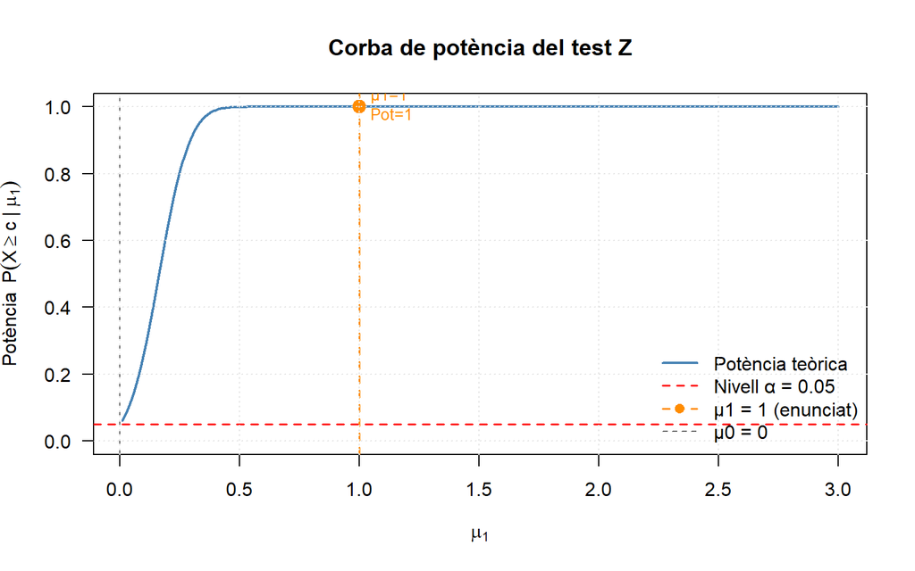

Corba de potència del test Z (n=100, σ=1, α=0.05)

```r
mu1_grid  <- seq(0.01, 3, by = 0.01)
potencies <- 1 - pnorm(c_100, mean = mu1_grid, sd = sigma / sqrt(n))

plot(mu1_grid, potencies,
     type = "l", lwd = 2, col = "steelblue",
     xlab = expression(mu[1]),
     ylab = expression("Potència  " * P(bar(X) >= c ~ "|" ~ mu[1])),
     main = "Corba de potència del test Z",
     ylim = c(0, 1), las = 1)

abline(h = alpha, lty = 2, col = "red",        lwd = 1.5)
abline(h = 1,     lty = 3, col = "gray40",     lwd = 1.0)
abline(v = mu0,   lty = 2, col = "gray40",     lwd = 1.0)
abline(v = mu1,   lty = 2, col = "darkorange", lwd = 1.5)

pot_1 <- 1 - pnorm(c_100, mean = 1, sd = sigma / sqrt(n))
points(1, pot_1, pch = 19, col = "darkorange", cex = 1.5)
text(1, pot_1,
     labels = paste0("μ1=1\nPot=", round(pot_1, 3)),
     pos = 4, col = "darkorange", cex = 0.85)

legend("bottomright",
       legend = c("Potència teòrica", paste0("Nivell α = ", alpha),
                  "μ1 = 1 (enunciat)", "μ0 = 0"),
       col = c("steelblue", "red", "darkorange", "gray40"),
       lty = c(1, 2, 2, 2), lwd = c(2, 1.5, 1.5, 1),
       pch = c(NA, NA, 19, NA), bty = "n")

grid(col = "gray90")
```

### Figura 2: corbes per a múltiples mides mostrals

Fixem $\mu_0$, $\mu_1$ i $\alpha$, i variïem $n$. Per a cada $n$, el valor crític canvia ($c_n = \mu_0 + z_{1-\alpha}\,\sigma/\sqrt{n}$), però la fórmula de la potència és la mateixa. L’efecte és que la corba es desplaça cap a l’**esquerra** i s’**empina** a mesura que $n$ creix.

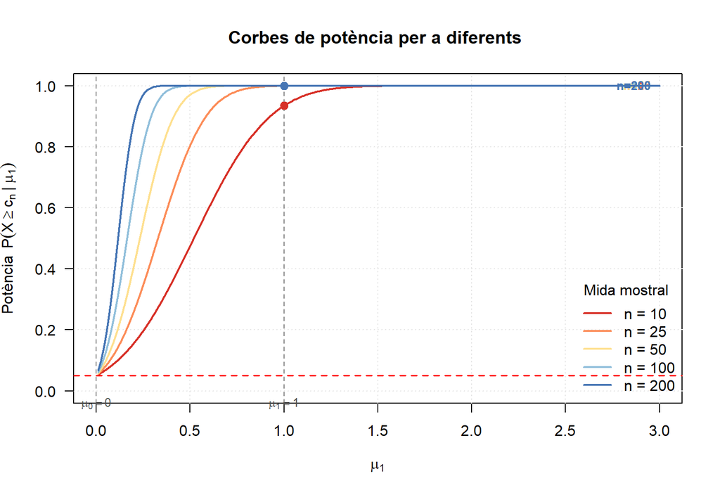

Corbes de potència per a diferents mides mostrals (σ=1, α=0.05)

```r
ns     <- c(10, 25, 50, 100, 200)
colors <- c("#d73027", "#fc8d59", "#fee090", "#91bfdb", "#4575b4")  # paleta divergent

mu1_grid <- seq(0.01, 3, by = 0.005)

# Gràfic base buit
plot(NA,
     xlim = c(0, 3), ylim = c(0, 1),
     xlab = expression(mu[1]),
     ylab = expression("Potència  " * P(bar(X) >= c[n] ~ "|" ~ mu[1])),
     main = "Corbes de potència per a diferents ",
     las = 1)

grid(col = "gray90")

# Dibuixem una corba per a cada n
for (i in seq_along(ns)) {
  ni    <- ns[i]
  c_ni  <- mu0 + qnorm(1 - alpha) * sigma / sqrt(ni)
  pot_i <- 1 - pnorm(c_ni, mean = mu1_grid, sd = sigma / sqrt(ni))
  lines(mu1_grid, pot_i, lwd = 2, col = colors[i])

  # Etiqueta al final de cada corba (a mu1 = 3)
  pot_end <- 1 - pnorm(c_ni, mean = 3, sd = sigma / sqrt(ni))
  text(3, pot_end, labels = paste0("n=", ni),
       pos = 2, col = colors[i], cex = 0.8, font = 2)
}

# Línies de referència
abline(h = alpha, lty = 2, col = "red",    lwd = 1.5)
abline(v = mu0,   lty = 2, col = "gray50", lwd = 1.0)
abline(v = mu1,   lty = 2, col = "gray50", lwd = 1.0)

# Marcar mu1=1 per a cada n
for (i in seq_along(ns)) {
  ni   <- ns[i]
  c_ni <- mu0 + qnorm(1 - alpha) * sigma / sqrt(ni)
  pot  <- 1 - pnorm(c_ni, mean = 1, sd = sigma / sqrt(ni))
  points(1, pot, pch = 19, col = colors[i], cex = 1.2)
}

legend("bottomright",
       legend = paste0("n = ", ns),
       col = colors, lty = 1, lwd = 2, bty = "n",
       title = "Mida mostral")

text(1, -0.04, expression(mu[1]==1), xpd = TRUE, cex = 0.8, col = "gray30")
text(0, -0.04, expression(mu[0]==0), xpd = TRUE, cex = 0.8, col = "gray30")
```

**Interpretació conjunta de les dues figures:**

- **Forma comuna:** totes les corbes comparteixen la mateixa forma sigmoïdal, amb potència $\to \alpha$ quan $\mu_1 \to \mu_0$ i potència $\to 1$ quan $\mu_1 \to \infty$. Això és una propietat del test, no de $n$.
- **Efecte de $n$:** augmentar la mida mostral *estira* la corba cap a l’esquerra i l’empina. Formalment, la potència depèn de $\mu_1$ a través del terme $(\mu_1 - \mu_0)\sqrt{n}/\sigma$: multiplicar $n$ per 4 equival a doblar la separació $(\mu_1 - \mu_0)$.
- **Punt $\mu_1 = 1$ (punts sòlids):** per $n = 10$ la potència és modesta ($\approx$ 0.94), mentre que per $n = 200$ és pràcticament 1. Això il·lustra que la mateixa diferència $\mu_1 - \mu_0$ pot ser estadísticament indetectable o gairebé certa de detectar, depenent de $n$.
- **Planificació mostral:** la Figura 2 permet respondre preguntes del tipus *“quina $n$ necessito per tenir potència $\geq 0.8$ si $\mu_1 = 0.5$?”* simplement identificant quina corba creua el llindar 0.8 per $\mu_1 = 0.5$. La solució analítica és $n \geq \left(\frac{(z_{1-\alpha} + z_{1-\beta})\,\sigma}{\mu_1 - \mu_0}\right)^2$.

## 6. Conclusions

- El **Lema de Neyman–Pearson** porta directament al **test Z** (o $t$ si $\sigma$ fos desconeguda): rebutjar $H_0$ quan $\bar{X} \geq \mu_0 + z_{1-\alpha}\,\sigma/\sqrt{n}$.
- Aquí el nivell real del test coincideix exactament amb el nivell nominal $\alpha$ (no hi ha conservadorisme).
- La potència creix amb $n$: augmentar la mida mostral desplaça la corba cap a l’esquerra, detectant diferències cada vegada més petites.
- La **distància estandarditzada** $\delta = (\mu_1 - \mu_0)/\sigma$ (mida de l’efecte) és el factor clau: la potència depèn de $\mu_1$ únicament a través de $\delta\sqrt{n}$.